# Aufgabe 11.2 – Fehlende Wochen durch bekannte Methoden ergänzen

**APPROVED – fachliche Freigabe vom 26.10.2026; Merge-Erlaubnis ausstehend.** KI-Unterstützung: Codex erstellte Code, Erläuterungen, Tests und Exporte. Das studentische Originalreview ist unverändert in `reviews/exercise_11_2.md` dokumentiert.

Quellen (am 26.10.2026 tatsächlich gelesen): [Aufgabe 11.2](https://noxthot.github.io/ws26_industrial_datascience_manuscript/1_act1/7_self_study_session2.html) und [Kapitel 5, Imputationsmethoden](https://noxthot.github.io/ws26_industrial_datascience_manuscript/1_act1/1_0_data_imputation.html).

Ziel: die **bereits geglättete Reihe mit Lücken aus 11.1** verwenden, mehrere bekannte Imputationsmethoden erproben, mit der Kursfunktion visualisieren und Ergebnisse diskutieren. Keine erneute Glättung und keine STL-Zerlegung (11.3).

```python
from pathlib import Path
import sys
import json
import numpy as np
import pandas as pd
import matplotlib.pyplot as plt
import seaborn as sns
from IPython.display import display

ROOT = Path.cwd().resolve()
if not (ROOT / "pyproject.toml").exists():
    raise RuntimeError("Notebook vom Projektstamm ausführen")
sys.path.insert(0, str(ROOT))
from sessions.ch11.production import SHA256
from sessions.ch11.imputation import load_smoothed_input, impute_series, gap_table, summarize_methods, METHODS, INPUT_SHA256
from sessions.ch11.imputation_plots import plot_imputation, plot_longest_gap
sns.set_theme(style="whitegrid")
OUTPUT = ROOT / "outputs/ch11/exercise_11_2"
OUTPUT.mkdir(parents=True, exist_ok=True)
frame, smoothed = load_smoothed_input()
original = smoothed.copy()
gaps = gap_table(smoothed)
print(f"Wochen: {len(smoothed)}; beobachtet: {smoothed.notna().sum()}; fehlend: {smoothed.isna().sum()}")
print(f"Lückenblöcke: {len(gaps)}; Länge: {gaps.weeks.min()}–{gaps.weeks.max()} Wochen")
print("Randlücken:", bool(smoothed.isna().iloc[0]), bool(smoothed.isna().iloc[-1]))
display(gaps[["start", "end", "weeks"]].head())
```

```
Wochen: 1044; beobachtet: 677; fehlend: 367
Lückenblöcke: 32; Länge: 3–23 Wochen
Randlücken: False False
```

|  | start | end | weeks |
| --- | --- | --- | --- |
| 0 | 2006-03-26 | 2006-07-02 | 15 |
| 1 | 2006-08-13 | 2006-11-26 | 16 |
| 2 | 2007-06-10 | 2007-06-24 | 3 |
| 3 | 2008-03-23 | 2008-06-01 | 11 |
| 4 | 2008-06-29 | 2008-10-05 | 15 |

## Eingabe und Annahmen

Die unveränderte synthetische Kurs-CSV wird über den bestehenden Download mit SHA256 geprüft. Der freigegebene 5-Wochen-Median aus 11.1 wird deterministisch reproduziert; ein zusätzlicher kanonischer Hash über Werte und Lückenmaske schützt die Eingabegleichheit. Die Moduldateien und Ergebnisse von 11.1 werden nicht verändert.

Es liegen 1.044 Sonntagswochen vom 02.01.2005 bis 29.12.2024 vor. Die 367 fehlenden Werte bilden 32 zusammenhängende Lücken von 3 bis 23 Wochen. Beide Randwochen sind beobachtet. Lange Ausfälle sind also keine einzelnen fehlenden Punkte; eine glatte Ergänzung kann deren tatsächlichen Produktionsverlauf nicht rekonstruieren.

`pieces` ist vollständig, aber selbst gestört und außerhalb der Lücken nicht identisch mit `pieces_gaps`. Sie wird nur in der Kursgrafik als Kontext gezeigt, nicht zum Füllen oder Optimieren verwendet. Es gibt hier keine fehlerfreie Referenz und folglich keine belastbare Genauigkeitsrangliste.

Datenquelle und Lizenzgrenze: `data/raw/PRODUCTION_SOURCE.md` (Kursseite CC BY-NC-SA 4.0, keine separate CSV-Lizenz angegeben). Keine Zufallsberechnung, kein Seed erforderlich.

## Definitionen und Randbehandlung

Für eine Lücke zwischen bekannten Werten xₐ und xᵦ:

- **Forward Fill:** x̂ₜ = xₐ, zuletzt bekannter Wert. Führende Lücken bleiben ohne Vorgänger offen.
- **Backward Fill:** x̂ₜ = xᵦ, nächster bekannter Wert. Nachlaufende Lücken bleiben ohne Nachfolger offen.
- **Linear:** x̂ₜ = xₐ + (xᵦ − xₐ) · (t − a)/(b − a). Bei den regelmäßigen Wochen entsprechen Positionsabstände Zeitabständen.
- **Polynom Grad 2/5:** stückweise Interpolation der jeweiligen Ordnung über bekannte Stützwerte (pandas/SciPy), kein globales Trendpolynom über alle 20 Jahre. Höhere Ordnung erlaubt Krümmung, kann aber stark überschwingen.
- **PCHIP:** stückweise kubisches Hermite-Interpolationspolynom mit formbewahrenden Ableitungen. Auf monotonen Abschnitten werden künstliche Überschwinger zwischen den Randwerten vermieden; saisonale Verläufe innerhalb langer Lücken werden trotzdem nicht erkannt.

Bei linearer, polynomialer und PCHIP-Interpolation begrenzen wir mit `limit_area="inside"` auf innere Lücken. Keine stille Extrapolation; negative oder extreme Resultate würden offengelegt statt nachträglich abgeschnitten. Alle ursprünglich vorhandenen geglätteten Werte bleiben unverändert. Beim vorliegenden Datensatz sind sämtliche Lücken innenliegend.

Dies ist ein rückblickender Bericht: spätere Stützwerte sind verfügbar. Backward Fill und Interpolationen nutzen Zukunftsinformation; schon die 11.1-Eingabe ist zentriert geglättet. Auch Forward Fill macht diese gesamte Pipeline daher nicht zu einer zulässigen Echtzeitprognose. Ein Prognosebenchmark würde chronologische Splits und innerhalb jedes Splits berechnete Vorverarbeitung benötigen.

```python
results = pd.DataFrame({method: impute_series(smoothed, method) for method in METHODS})
for method in METHODS:
    pd.testing.assert_series_equal(results.loc[smoothed.notna(), method], smoothed.dropna(), check_names=False)
    assert results[method].isna().sum() == 0
pd.testing.assert_series_equal(smoothed, original)
summary = summarize_methods(smoothed, results)
display(summary.rename(index=METHODS).round(3))
print("Alle sechs Verfahren ergänzen jeweils", int(smoothed.isna().sum()), "Wochen.")
```

| method | filled | remaining | imputed_min | imputed_max | negative_imputed | outside_gap_anchors |
| --- | --- | --- | --- | --- | --- | --- |
| Forward Fill | 367 | 0 | 302.332 | 1088.013 | 0 | 0 |
| Backward Fill | 367 | 0 | 227.307 | 1113.291 | 0 | 0 |
| Linear | 367 | 0 | 235.048 | 1108.236 | 0 | 0 |
| Polynom Grad 2 | 367 | 0 | 228.031 | 1112.513 | 0 | 78 |
| Polynom Grad 5 | 367 | 0 | 192.056 | 1113.678 | 0 | 189 |
| PCHIP | 367 | 0 | 228.620 | 1110.663 | 0 | 0 |

```
Alle sechs Verfahren ergänzen jeweils 367 Wochen.
```

## Diagnosegrößen richtig lesen

`filled` und `remaining` zählen ergänzte bzw. noch fehlende Wochen. Minimum, Maximum und negative Werte beziehen sich ausschließlich auf ursprünglich fehlende Wochen. `outside_gap_anchors` zählt Ergänzungen außerhalb des Werteintervalls der beiden direkt benachbarten bekannten Randwerte (numerische Toleranz 10⁻⁹ Stück).

Ein Überschreiten dieses Intervalls ist ein Hinweis auf Krümmung/Überschwingen, kein bewiesener Fehler: ein realer saisonaler Gipfel könnte ebenfalls außerhalb liegen. Umgekehrt belegt ein Verlauf innerhalb der Randwerte keine Genauigkeit. Wir berichten Diagnostik, keine Fehlermaße gegen eine behauptete Ground Truth.

### Forward Fill

Dreiteilige Kursdarstellung: vollständige Vergleichsreihe, geglättete Eingabe mit Lücken, ausschließlich ergänzte Wochen. Die 11.2-spezifische Anpassung erhält NaNs im Linienpfad, damit getrennte Lücken nicht miteinander verbunden werden.

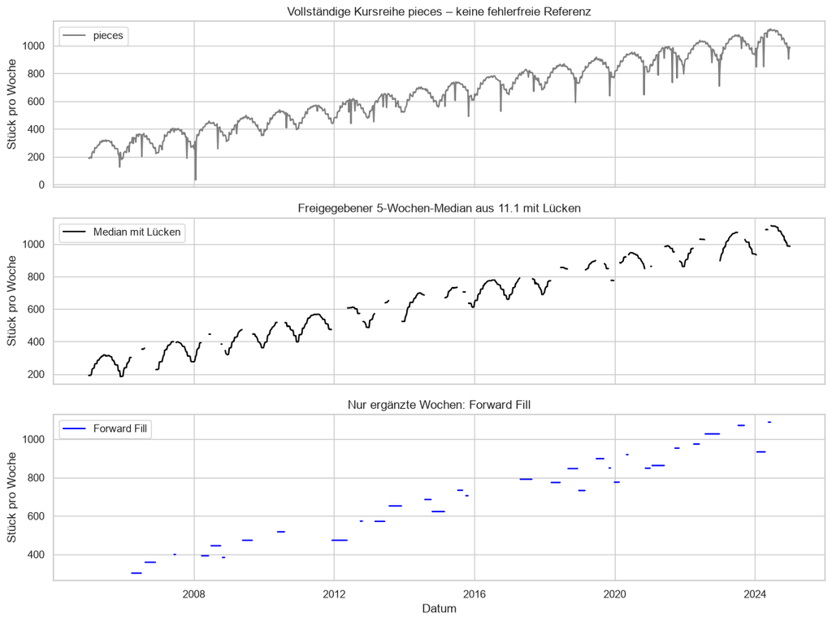

```python
fig = plot_imputation(frame, smoothed, results["ffill"], "ffill")
fig.savefig(OUTPUT / "ffill.png", dpi=140)
plt.show()
```

### Backward Fill

Dreiteilige Kursdarstellung: vollständige Vergleichsreihe, geglättete Eingabe mit Lücken, ausschließlich ergänzte Wochen. Die 11.2-spezifische Anpassung erhält NaNs im Linienpfad, damit getrennte Lücken nicht miteinander verbunden werden.

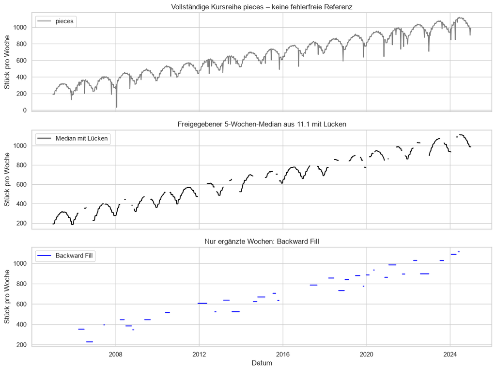

```python
fig = plot_imputation(frame, smoothed, results["bfill"], "bfill")
fig.savefig(OUTPUT / "bfill.png", dpi=140)
plt.show()
```

### Lineare Interpolation

Dreiteilige Kursdarstellung: vollständige Vergleichsreihe, geglättete Eingabe mit Lücken, ausschließlich ergänzte Wochen. Die 11.2-spezifische Anpassung erhält NaNs im Linienpfad, damit getrennte Lücken nicht miteinander verbunden werden.

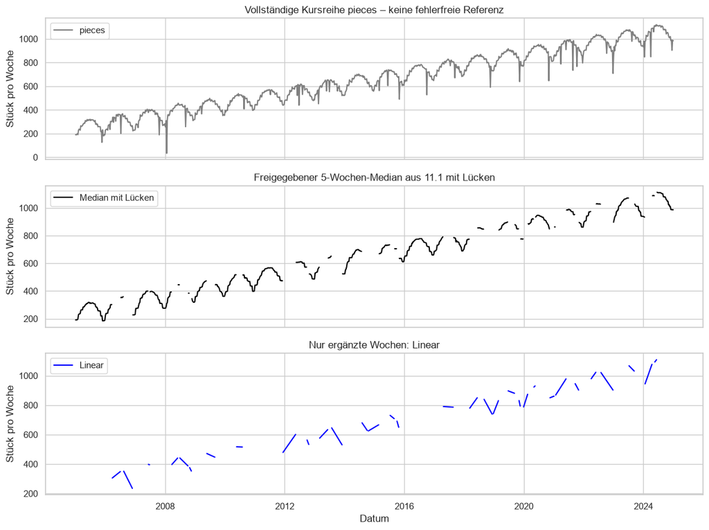

```python
fig = plot_imputation(frame, smoothed, results["linear"], "linear")
fig.savefig(OUTPUT / "linear.png", dpi=140)
plt.show()
```

### Polynom Grad 2

Dreiteilige Kursdarstellung: vollständige Vergleichsreihe, geglättete Eingabe mit Lücken, ausschließlich ergänzte Wochen. Die 11.2-spezifische Anpassung erhält NaNs im Linienpfad, damit getrennte Lücken nicht miteinander verbunden werden.

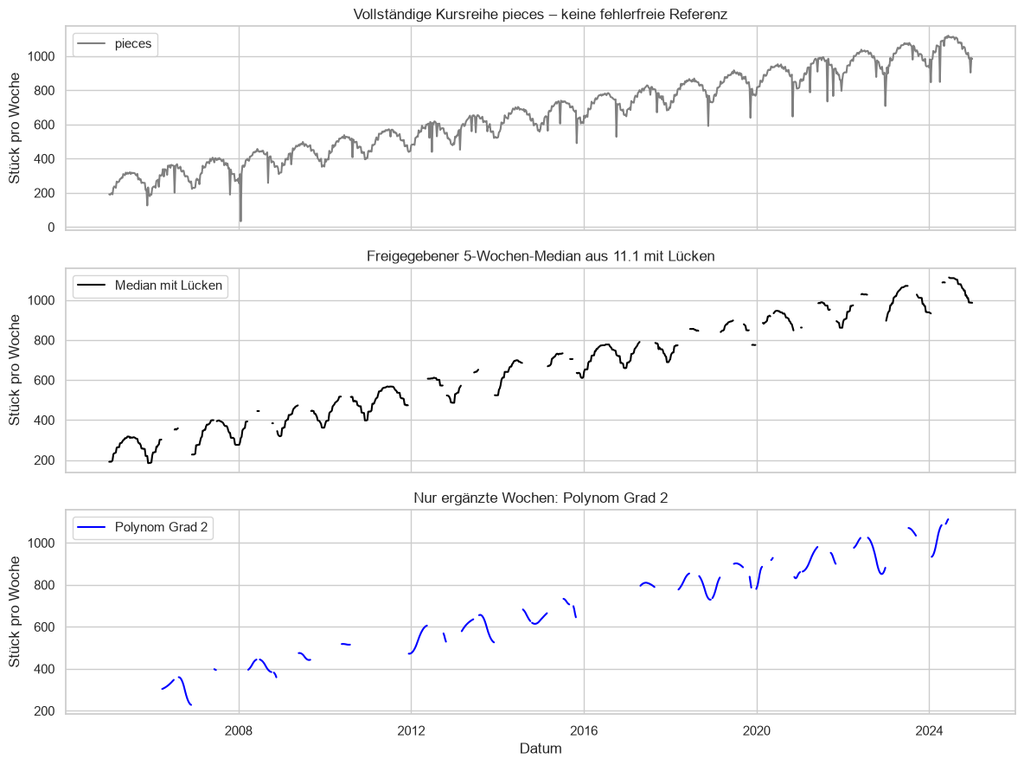

```python
fig = plot_imputation(frame, smoothed, results["polynomial2"], "polynomial2")
fig.savefig(OUTPUT / "polynomial2.png", dpi=140)
plt.show()
```

### Polynom Grad 5

Dreiteilige Kursdarstellung: vollständige Vergleichsreihe, geglättete Eingabe mit Lücken, ausschließlich ergänzte Wochen. Die 11.2-spezifische Anpassung erhält NaNs im Linienpfad, damit getrennte Lücken nicht miteinander verbunden werden.

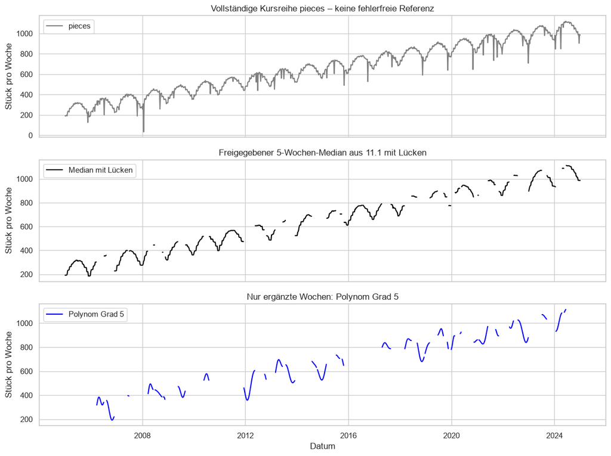

```python
fig = plot_imputation(frame, smoothed, results["polynomial5"], "polynomial5")
fig.savefig(OUTPUT / "polynomial5.png", dpi=140)
plt.show()
```

### PCHIP

Dreiteilige Kursdarstellung: vollständige Vergleichsreihe, geglättete Eingabe mit Lücken, ausschließlich ergänzte Wochen. Die 11.2-spezifische Anpassung erhält NaNs im Linienpfad, damit getrennte Lücken nicht miteinander verbunden werden.

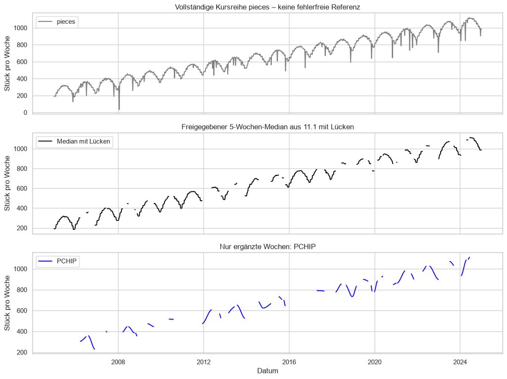

```python
fig = plot_imputation(frame, smoothed, results["pchip"], "pchip")
fig.savefig(OUTPUT / "pchip.png", dpi=140)
plt.show()
```

## Gemeinsamer Vergleich an einer langen Lücke

Der Ausschnitt wird deterministisch über die erste längste Lücke ausgewählt, nicht nach dem günstigsten Ergebnis eines Verfahrens. Die schwarzen Punkte sind bekannte Medianwerte; die graue Fläche markiert den fehlenden Zeitraum.

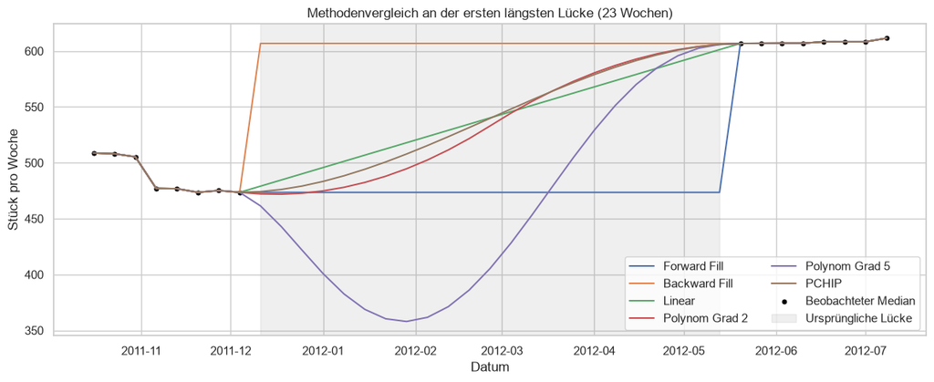

```
Erste längste Lücke: 2011-12-11 bis 2012-05-13 (23 Wochen)
```

```python
fig = plot_longest_gap(smoothed, results)
fig.savefig(OUTPUT / "longest_gap_comparison.png", dpi=140)
plt.show()
longest = gaps.sort_values(["weeks", "start"], ascending=[False, True]).iloc[0]
print("Erste längste Lücke:", longest.start.date(), "bis", longest.end.date(), f"({int(longest.weeks)} Wochen)")
```

## Diskussion und Schlussfolgerung

Forward und Backward Fill erzeugen konstante Abschnitte auf unterschiedlichen Niveaus; ihre Abweichung bei langen Ausfällen zeigt die Bedeutung der Zeitrichtung. Lineare Interpolation verbindet die Randpunkte mit einer Geraden, blendet aber mögliche saisonale Schwankungen dazwischen aus. PCHIP verändert die Krümmung und ist formbewahrend, rekonstruiert jedoch ebenfalls keine unbekannte Saison innerhalb einer Lücke.

Die Polynomvarianten sind flexibler. Besonders Grad 5 kann zwischen entfernten Stützstellen stark ausschlagen; die gemeinsame Grafik und die tatsächlich berechnete Diagnoseübersicht machen diese Empfindlichkeit sichtbar. Bei Grad 2 liegen 78, bei Grad 5 sogar 189 der 367 Ergänzungen außerhalb der jeweiligen Lückenrandwerte. Bei den übrigen vier Verfahren sind es null. Keines der sechs Verfahren erzeugt negative Ergänzungen. Dies beschreibt die Form der Schätzung, nicht ihre unbekannte Genauigkeit. Glätte allein ist kein Qualitätsbeweis. Alle sechs Verfahren füllen die 367 fehlenden Wochen, da keine Randlücken vorliegen; kein Verfahren verändert die 677 vorhandenen Medianwerte.

Für eine transparente einfache Darstellung ist die lineare Interpolation ein nachvollziehbarer Ausgangspunkt; PCHIP ist eine formbewahrende Alternative. Diese Einschätzung beruht auf Einfachheit und sichtbarer Form, nicht auf nachgewiesener höherer Genauigkeit. Die ursprünglichen Beobachtungen und die ergänzten Schätzwerte bleiben getrennt verfügbar. Lange Lücken bis 23 Wochen begrenzen jede inhaltliche Schlussfolgerung; eine vollständige Jahresproduktion sollte daher nicht als exakt gemessene Summe dieser Ergänzungen ausgegeben werden.

Die geglättete Eingabe kann echte kurze Ereignisse bereits gedämpft haben. Es erfolgt keine zusätzliche Glättung, keine automatische Ausreißerkorrektur und keine STL-Analyse. Die Methodenwahl für einen endgültigen Managementbericht bedarf des studentischen Reviews.

```python
processed = pd.concat([frame, smoothed, results.add_prefix("imputed_")], axis=1)
processed.to_csv(ROOT / "data/processed/exercise_11_2_imputed.csv")
gaps.to_csv(OUTPUT / "gaps.csv", index=False)
summary.to_csv(OUTPUT / "method_summary.csv")
checks = {"rows": len(smoothed), "missing_input": int(smoothed.isna().sum()),
          "gap_blocks": len(gaps), "longest_gap_weeks": int(gaps.weeks.max()),
          "methods": list(METHODS), "remaining_by_method": results.isna().sum().to_dict(),
          "observed_values_unchanged": True, "raw_sha256": SHA256,
          "approved_smoothed_input_sha256": INPUT_SHA256}
(OUTPUT / "summary.json").write_text(json.dumps(checks, indent=2) + "\n", encoding="utf-8")
display(pd.Series(checks, name="Technische Übersicht"))
```

```
rows                                                                           1044
missing_input                                                                   367
gap_blocks                                                                       32
longest_gap_weeks                                                                23
methods                           [ffill, bfill, linear, polynomial2, polynomial...
remaining_by_method               {'ffill': 0, 'bfill': 0, 'linear': 0, 'polynom...
observed_values_unchanged                                                      True
raw_sha256                        6310fd9e1fb081929f29715716dca3c433780a09d69c3a...
approved_smoothed_input_sha256    7db834208a47d1045b94afb2a91b14497b5970699f9eb2...
Name: Technische Übersicht, dtype: object
```

## Fragen für dein wissenschaftliches Review

1. Ist die Trennung zwischen beobachteten Medianwerten und ergänzten Schätzungen in allen Grafiken nachvollziehbar?
2. Sind Linear/PCHIP als einfache Ausgangspunkte und die Risiken der Polynome anhand des Vergleichs überzeugend begründet?
3. Wie sollte ein Managementbericht eine bis zu 23 Wochen lange Lücke und die daraus folgende Unsicherheit kommunizieren?
4. Ist klar, weshalb keine Genauigkeitsrangliste gegen pieces und keine Echtzeitprognose behauptet werden?

Status und tatsächliche Prüfergebnisse: `reviews/exercise_11_2.md`. Positive studentische Freigabe vom 26.10.2026 dokumentiert; kein Merge ohne ausdrückliche Erlaubnis.